# Comprendre les SHapley Additive exPlanations

Plusieurs challenges peuvent dissuader de mettre un modèle en production :

- la distribution d'un phénomène modélisé peut changer avec le temps, rendant par là même caduques les prédictions*,
- le modèle peut requérir un temps important pour prédire de nouvelles observations,
- et sa complexité le rendre peu interprétable/acceptable auprès des utilisateurs finaux.

* À cet effet, l’ACPR distingue la validation initiale de la validation continue des modèle, afin de s’assurer en permanence que les décisions qu’ils prennent font sens.

Sur ce dernier point, il existe une méthode permettant de concillier la performance de modèles complexes (ex : RF, GBM, SVM, ... ) avec l'interprétabilité inhérente de modèles plus simples (ex : GLM, arbre, ... ).

Ce notebook implémente l'article [*A Unified Approach to Interpreting Model Predictions*](https://arxiv.org/pdf/1705.07874.pdf), dans le cas d'une random forest dont on cherche à expliquer la contribution de chaque variable utilisée pour prédire une nouvelle observation. C'est justement le but des *SHAP values*.

NB : bien que mi-théorique mi-technique, cet article pour être compris ne requiert ni la connaissance du langage Python ni de doctorat en mathématique. Il suffit d'ignorer le code et de se référer aux sorties à la place.

Ce notebook s'exécute en ~1 mn 30 s.

**Sommaire :**

1. Présentation générale de la méthode
   1. Terminologies
   2. Création de données fictives et modélisation basique
   3. Le package SHAP
   4. Waterfall chart de la contribution des variables à la prédiction d'une observation
   5. Interprétation globale du modèle
   6. Théorie derrière les valeurs de Shapley - vérification des 4 propriétés théoriques
2. Implémentation en python
   1. Création des coalitions
   2. Génération des poids
   3. Génération des instances perturbées
   4. Prédiction du modèle lorsque les instances sont perturbées
   5. Putting it all together
3. Conclusions

## Présentation générale de la méthode

Le mathématicien Loyd Shapley est à l'origine des *Shapley values*, une méthode issue de la théorie des jeux coopératifs.

Cette méthode est :

- *model agnostic* : elle permet d'expliquer la prédiction de n'importe quel modèle, paramétrique ou non, ensembliste ou non.
- *locale*, au sens où elle explique avant tout une prédiction à un niveau micro, plutôt que le fonctionnement global d'un modèle (comme le ferait par exemple la *feature importance* d'une forêt aléatoire).

### Terminologies

- $X$ la matrice d'entraînement des observations $x_i$,
- $m$ son nombre de variables (qu'elles soient explicatives ou non) et $n$ son nombre d'observations,
- $f(x_i)$ un modèle complexe (une forêt aléatoire p. ex.) que l'on cherche à expliquer par
- $g(x_i)$, un modèle simple (régression linéaire), explicatif **localement$^*$**de $f$.

Métaphoriquement parlant, $m$ joueurs (variables) collaborent ensemble à un jeu et obtiennent un gain (la prédiction). Comment répartir ce gain de façon équitable entre les joueurs, c'est-à-dire de façon proportionnelle à leur contribution individuelle ?

```python
# Import de quelques packages

from itertools import chain, combinations
from math import factorial

import numpy as np
import pandas as pd
from matplotlib import pyplot as plt
from sklearn.base import BaseEstimator
from sklearn.ensemble import RandomForestRegressor

import shap ; shap.initjs() # conda install -c conda-forge shap
```

### Création de données fictives et modélisation basique

Soit un jeu de 10 000 données artificielles à 5 variables dont on admet que la loi est connue et déterministe : $$y_i = 3a_i - b_i + 4d_i + 0.5e_i ~~\forall i$$

La variable `C` est volontairement absente du processus générateur : dans la vie de tous les jours, ce n'est pas parce que l'on dispose d'une variable qu'elle est forcément explicative.

```python
n = 10_000
train = {lettre: np.round(np.random.rand(n), 4) for lettre in list('ABCDE')}
train = pd.DataFrame(train)
train['target'] = 3*train.A - train.B + 4*train.D + 0.5*train.E  # C est donc non-informative
train.tail(3)
```

|  | A | B | C | D | E | target |
| --- | --- | --- | --- | --- | --- | --- |
| 9997 | 0.2559 | 0.8683 | 0.9577 | 0.3010 | 0.5914 | 1.39910 |
| 9998 | 0.9655 | 0.3224 | 0.3219 | 0.4733 | 0.6044 | 4.76950 |
| 9999 | 0.2748 | 0.7099 | 0.6321 | 0.9678 | 0.4627 | 4.21705 |

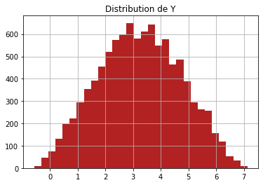

```python
# À titre informatif...
train.target.hist(color='firebrick', bins=30) ; plt.title('Distribution de Y') ;
```

Il va sans dire qu'étant donné la nature linéaire du problème, une régression ferait sans doute l'affaire... Cependant, notre but étant d'expliquer la prédiction d'un modèle complexe, on lui préfèrera ici un modèle ensembliste, par exemple une forêt aléatoire.

Nul besoin d'échantillon de validation ici, l'interprétation nous intéressant davantage que la performance. Pour la même raison, on s'abstient de calibrer les hyperparamètres du modèle.

```python
rf = RandomForestRegressor(n_estimators=100, random_state=42)
rf.fit(train.drop('target', 1), train['target']);
```

Créons une nouvelle observation issue du même processus générateur que les données d'entraînement. Cette nouvelle observation peut être considérée comme un échantillon de test composé d'une unique ligne.

```python
nouvelle_obs = pd.DataFrame({lettre: np.random.rand(1) for lettre in 'ABCDE'} )
nouvelle_obs['target'] = 3   * nouvelle_obs.A \
                       - 1   * nouvelle_obs.B \
                       + 4   * nouvelle_obs.D \
                       + 0.5 * nouvelle_obs.E
nouvelle_obs
```

|  | A | B | C | D | E | target |
| --- | --- | --- | --- | --- | --- | --- |
| 0 | 0.576894 | 0.00313 | 0.99145 | 0.158667 | 0.228716 | 2.476577 |

Le modèle déjà entraîné peut prédire cette observation :

```python
prediction = rf.predict(nouvelle_obs.drop('target', 1))[0]
prediction
```

```
2.5052455000000005
```

La prédiction n'est pas loin de la vraie valeur ! Mais comment s'assurer que ce n'est pas "un coup de chance" ? Peut-on *interpréter* cette prédiction en dépit de la relative complexité du modèle utilisé ?

### Yes, we can $\rightarrow$ avec le package [shap](https://github.com/slundberg/shap#citations)

La méthode considère chaque variable est comme un joueur.

L'ensemble des joueurs forme une coalition dont la collaboration aboutie à la prédiction $y_i$ du modèle.

Quels joueurs ont contribué à cette prédiction, et à quelle hauteur ? C'est à cette question que répondent les valeurs de Shapley. Chaque valeur $\phi_j$ s'interprète comme la contribution de la $j$-ième variable à la prédiction de l'observation considérée.

```python
explainer = shap.KernelExplainer(rf.predict, train.drop('target', 1))

X_test = nouvelle_obs.drop('target', 1)
shap_values = explainer.shap_values(X_test, l1_reg="num_features(10)")

shapley_values_dict = dict(zip('ABCDE', shap_values[0]))
shapley_values_df = pd.DataFrame(shapley_values_dict, index=['Valeurs de Shapley par variable'])
shapley_values_df
```

```
Using 10000 background data samples could cause slower run times. Consider using shap.sample(data, K) or shap.kmeans(data, K) to summarize the background as K samples.
```

|  | A | B | C | D | E |
| --- | --- | --- | --- | --- | --- |
| Valeurs de Shapley par variable | 0.27012 | 0.412424 | 0.002201 | -1.332368 | -0.087917 |

On constate aisément les variables qui ont le plus influencé le modèle lors de sa prédiction : celles dont les SHAP values sont les plus élevées en valeurs absolues. Sur notre observation exemple, la variable $C$ n'a quasiment pas été utilisée dans la prédiction - ce qui est logique, car on rappelle que $C$ est par construction indépendante de la cible à prédire.

Conformément à la propriété *local accuracy*, on observe $$\widehat{y_i} \approx \mathbb{E}[Y] + \sum_{j = 1}^m \phi_j$$

En français, cela signifie que le modèle complexe est approximé localement au point $x_i$ par la régression linéaire $g(x)$, dont les coefficients $\phi_j$ sont les valeurs de Shapley, et $\mathbb{E}[Y]$ la constante ("intercept").

```python
print("Prédiction du modèle", prediction)
print("Somme des valeurs de Shapley :", train.target.mean() + shap_values.sum())
```

```
Prédiction du modèle 2.5052455000000005
Somme des valeurs de Shapley : 2.5052943667500003
```

La moyenne empirique de $Y$ sur l'échantillon d'entraînement est $\overline{y}_{train} = 3.241$. Par défaut, c'est la prédiction naïve que ferait un modèle s'il n'avait accès à aucune variable. Comment chaque variable a-t-elle influé sur cette prédiction naïve pour parvenir à la prédiction constatée $\hat{y}_{\text{nouvelle obs}}$?

```python
shap.force_plot(explainer.expected_value, shap_values, X_test)
```

[output not shown]

À l'instar des coefficients d'un modèle linéaire, plus la valeur absolue d'une valeur de Shapley est élevée, plus grande est la contribution de sa variable associée.

Ici, la variable B a contribué à augmenter la prédiction du modèle (2.51), à hauteur de 0.41. Tandis que la variable D a tiré la prédiction vers le bas à hauteur de -1.33.

### Waterfall chart de la contribution des variables à la prédiction d'une observation

```python
# On trie simplement les contributions_moyennes par valeurs absolues décroissantes :
clés_triées = sorted(shapley_values_dict, reverse=True,
                     key=lambda x: abs(shapley_values_dict[x]))
shapley_values_dict = {k: shapley_values_dict[k] for k in clés_triées}
shapley_values_dict
```

```
{'D': -1.3323681646366587,
 'B': 0.4124242194841684,
 'A': 0.27012033536750973,
 'E': -0.08791730147416454,
 'C': 0.0022009780091454267}
```

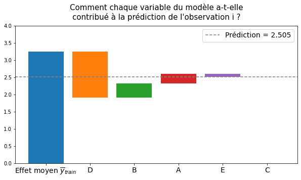

```python
plt.figure(figsize=(10, 5))

previous_hauteur = train.target.mean()
plt.bar([0], previous_hauteur)

for i, (variable, hauteur) in enumerate(shapley_values_dict.items(), start=1):
    plt.bar([i], hauteur, bottom=previous_hauteur)
    previous_hauteur += hauteur

xlabels = [r'Effet moyen $\overline{y}_{train}$'] + list(shapley_values_dict.keys())
plt.xticks(range(i+1), xlabels, fontsize=14) ;
plt.axhline(y=prediction, linestyle='--', c='gray', label=f'Prédiction = {prediction:.3f}')
plt.legend(fontsize=14)
titre = "Comment chaque variable du modèle a-t-elle\ncontribué à la prédiction de l'observation i ?"
plt.ylim(0, 4)
plt.title(titre, fontsize=15, pad=12);
```

La hauteur de chaque barre correspond à la valeur de Shapley et est proportionnelle à la contribution de la variable à la prédiction.

### Interprétation *globale* du modèle

Les valeurs de Shapley permettent d'expliquer une prédiction, à un niveau local donc. Pour se faire une idée du modèle globalement, il est possible de calculer les valeurs de Shapley de plusieurs observations caractéristiques du jeu de données. Et de les représenter comme ci-contre :

```python
nouvelles_observations = pd.DataFrame({lettre: np.random.rand(10) for lettre in 'ABCDE'} )
shap_values = explainer.shap_values(nouvelles_observations, l1_reg="num_features(10)")
```

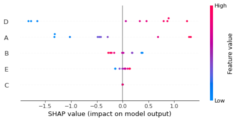

```python
shap.summary_plot(shap_values, nouvelles_observations)
```

Lecture : la variable D est celle qui influence le plus les décisions du modèle. Une valeur forte d'une observation pour cette variable augmentera les prédictions ; au contraire, de fortes valeurs pour la variable B sont assocées à de plus petites prédictions.

D'autres méthodes existent pour l'interprétation globale des modèles. On pourra citer les *partial dependance plots*, les *ICE-curve* ou encore les *ALE-plots*. Le lecteur curieux des forces et faiblesses de ces méthodes pourra se référer à [l'excellent mémoire de Dimitri Delcaillau](https://www.institutdesactuaires.com/global/gene/link.php).

On pourrait s'arrêter à la simple utilisation du package shap. Cependant, comprendre *comment* les SHAP values sont calculées n'est pas denué d'intérêt.

Considérons un sous-ensemble de cette problématique pour nous demander

**Comment la variable *D* a-t-elle contribué à la prédiction du modèle ?**

Intuitivement, la contribution d'une variable à une prédiction est l'écart absolu entre :

1. la prédiction que fait le modèle quand il dispose de cette variable, et
2. la prédiction que *ferait* le modèle si cette variable n'était pas disponible.

```python
team_members = set(train) - {'target'}
m = len(team_members)

print('team_members :', team_members)
print('m :', m)
```

```
team_members : {'E', 'C', 'A', 'B', 'D'}
m : 5
```

## Implémentation en python

### Création des coalitions

La première étape pour implémenter SHAP est la génération de coalitions.

```python
def genere_coalition(team_members: set, player: str):
    """
    Retourne toutes les coalitions possibles parmi team_members, mais SANS la variable player.
    Usage :
    >>> list(genere_coalition({'A', 'B', 'C', 'D'}, 'C'))
    [set(), {'D'}, {'A'}, {'B'}, {'D', 'A'}, {'D', 'B'}, {'A', 'B'}, {'D', 'A', 'B'}]
    """
    team_members = team_members - {player}
    combinaisons = (combinations(team_members, c) for c in range(len(team_members)+1))
    iterateur = chain(*combinaisons)
    return map(set, iterateur)

# Un exemple :
for coalition in genere_coalition({'A', 'B', 'C', 'D', 'E'}, 'D'):
    print(coalition)
```

```
set()
{'C'}
{'E'}
{'A'}
{'B'}
{'C', 'E'}
{'C', 'A'}
{'C', 'B'}
{'E', 'A'}
{'E', 'B'}
{'B', 'A'}
{'C', 'E', 'A'}
{'C', 'E', 'B'}
{'C', 'B', 'A'}
{'E', 'A', 'B'}
{'C', 'E', 'A', 'B'}
```

On vérifie aisément que toutes les coalitions sont bien générées. À combien de coalitions possibles doit-on s'attendre dans un ensemble de $m = 5$ variables ?

```python
def pascal(k, m):
    """ Retourne le nombre de combinaisons de k parmi m variables. """
    return factorial(m) / (factorial(k)*factorial(m-k))

def nb_coalitions_possibles(m):
    """
    Dans un ensemble de m variables, retourne le nombre de coalitions possibles une
    fois une variable d'intérêt écartée.
    Usage :
    >>> nb_coalitions_possibles(m=4)
    16
    """
    return sum([pascal(k, m) for k in range(0, m+1)])

print(f"Dans une équipe de 5 joueurs (=variables), il faut s'attendre à {nb_coalitions_possibles(m=5):.0f} coalitions possibles.")
```

```
Dans une équipe de 5 joueurs (=variables), il faut s'attendre à 32 coalitions possibles.
```

Une fois que l'on sait générer les coalitions, il faut encore être capable de déterminer *l'importance* (le poids) de chaque coalition. [On sait](https://arxiv.org/pdf/1705.07874.pdf) que pour toute coalition, ce poids est donné par : $$poids(coalition) = \frac{|coalition|!(m-|coalition|-1)!}{m!}$$

### Génération des poids

```python
def genere_poids(coalition, m):
    """
    Calcule le poids affecté à une `coalition` parmi m = |team_members| features.
    Usage :
    >>> genere_poids({'A', 'B'}, m=3)
    0.033333
    """
    if len(coalition) == m:
        return 0
    return factorial(len(coalition))*factorial(m-len(coalition)-1) / factorial(m)
```

Un exemple : un modèle *f* dispose au total de 3 features pour prédire : `A`, `B` et `C`. On cherche à comprendre la contribution de la feature `C` à la prédiction d'une instance *x*. Pour cela, on regarde l'apport de `C` à chaque coalition possible :

- si *f* n'a pas de variable VS s'il a `C` $\rightarrow$ ce test aura un poids de `(genere_poids({}, 3)` = 0.33
- si *f* dispose seulement de `A` VS s'il a `C` en plus $\rightarrow$ ce test aura un poids de `genere_poids({'A'}, 3)` = 0.16
- si *f* dispose seulement de `B` VS s'il a `C` en plus $\rightarrow$ ce test aura un poids de `genere_poids({'B'}, 3)` = 0.16
- si *f* dispose de `A` et `B` VS s'il a `C` en plus $\rightarrow$ ce test aura un poids de `genere_poids({'A', 'B'}, 3)` = 0.33

La somme des poids des tests fait bien 100 % :

```
assert genere_poids({}, 3) + genere_poids({'A'}, 3) + genere_poids({'B'}, 3) + genere_poids({'A', 'B'}, 3) == 1
```

Revenons à notre objectif de comprendre comment la variable $D$ a joué dans la décision de la random forest. Pour toutes les coalitions de joueurs dépourvues de $D$, on représente les poids associés :

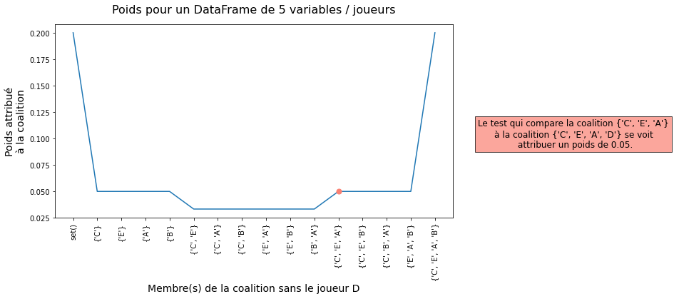

```python
variable_d_interêt = 'D'
coalitions = list(genere_coalition(team_members, variable_d_interêt))
poids = [genere_poids(coalition, len(team_members)) for coalition in coalitions]

plt.figure(figsize=(10, 5))
plt.plot(poids)

i = 11
plt.scatter(i, poids[i], s=50, color='salmon', zorder=3)
explication = f"Le test qui compare la coalition {coalitions[i]}\n"\
              f"à la coalition {coalitions[i] | {variable_d_interêt}} se voit\n"\
               f" attribuer un poids de {poids[i]:.2f}."
a, b = plt.ylim()
plt.text(plt.xlim()[1]+5, (b-a)/2, explication,
         ha='center', va='baseline', fontsize=12,
         bbox={'facecolor':'salmon', 'alpha':0.7});

plt.xlabel(r'Membre(s) de la coalition sans le joueur D', fontsize=14)
plt.xticks(np.arange(len(poids)), [str(c) for c in coalitions], rotation=90)
plt.ylabel('Poids attribué\nà la coalition', fontsize=14)
plt.title(f"Poids pour un DataFrame de {m} variables / joueurs", fontsize=16, pad=15);
assert round(sum(poids), 5) == 1
```

Ce shéma confirme que les petites coalitions et les larges récupèrent les plus fortes pondérations. L'intuition (pas forcément évidente de prime abord) est la suivante :

> *We learn most about individual features if we can study their effects in isolation. If a coalition consists of a single feature, we can learn about the features’ isolated main effect on the prediction. If a coalition consists of all but one feature, we can learn about this features’ total effect (main effect plus feature interactions). If a coalition consists of half the features, we learn little about an individual features contribution, as there are many possible coalitions with half of the features.*

> *Intuitively, this gives the highest weight to the most informative contributions of a player, i.e. when it is either isolated or when it is added to an otherwise full coalition.*

### Génération des instances perturbées

On sait donc évaluer le poids associé à une coalition de joueurs/variables. Dans la formule initiale, il reste à évaluer $model(coalition \cup j)$, sans la variable $j$ ni les features absentes de la coalition. Plusieurs options sont possibles :

- Pour chaque coalition, on réinstancie un modèle $f_{coalition}$ en conservant les hyperparamètres (nombre d'arbres, profondeur, etc.), que l'on entraîne seulement sur les features présentes dans la coalition. Cette solution, en plus d'être chronophage, requiert l'entraînement de modèles qui ne sont pas le modèle initial $f$ que l'on cherche à expliquer.
- On remplace les valeurs des variables qui ne sont pas dans la coalition par leur moyenne : $model(S \cup \mathbb{E}(colname))$
- On remplace les valeurs des variables qui ne sont pas dans la coalition par une valeur échantillonnée au hasard dans l'échantillon d'entraînement.

  > *We replace the feature values of features that are not in a coalition with random feature values [...] to get a prediction from the machine learning model ([source](https://christophm.github.io/interpretable-ml-book/shapley.html)).*

> *This means that we equate “feature value is absent” with “feature value is replaced by random feature value from train.*

> *ML implementations of Shapley values, and specifically the SHAP method, interpret missing features as features whose value is unknown, and simulate this unknown state by averaging over possible values of the feature.*

C'est cette dernière option qui est retenue par SHAP.

```python
nouvelle_obs
```

|  | A | B | C | D | E | target |
| --- | --- | --- | --- | --- | --- | --- |
| 0 | 0.576894 | 0.00313 | 0.99145 | 0.158667 | 0.228716 | 2.476577 |

Afin de "perturber les observations prédites", nous générons des observations aléatoires à partir du jeu d'entraînement :

```python
def genere_masque(df_train: pd.DataFrame, nb_replicas: int = 1):
    """
    Génère un masque de même format que l'observation `df_test` à expliquer,
    à ceci près que chaque cellule est remplacée par une valeur
    tirée aléatoirement dans l'échantillon d'entraînement.

    Attention, cette façon de procéder n'empêche pas la création ponctuelle
    d'observations atypiques que le modèle serait bien en pein de prédire...
    """
    sample = df_train.sample(nb_replicas, replace=True)
    return sample.drop('target', 1).reset_index(drop=True)

# Test :
mask = genere_masque(train, nb_replicas=4)
mask
```

|  | A | B | C | D | E |
| --- | --- | --- | --- | --- | --- |
| 0 | 0.3707 | 0.5993 | 0.1532 | 0.0514 | 0.5995 |
| 1 | 0.8397 | 0.5033 | 0.5329 | 0.8700 | 0.3493 |
| 2 | 0.6542 | 0.6807 | 0.2905 | 0.7732 | 0.2781 |
| 3 | 0.3633 | 0.3969 | 0.2163 | 0.1832 | 0.0797 |

```python
def perturbe_instance(df_test: pd.DataFrame, mask: pd.DataFrame, coalition: set):
    """
    Perturbe l'instance `df_test` en appliquant le masque aléatoire (uniquement)
    sur les variables de la coalition.
    Génère len(mask) nouvelles observations aléatoirement perturbées.
    """
    instance_perturbee = mask.copy()
    for feature in coalition:
        instance_perturbee[feature] = df_test[feature][0]

    return instance_perturbee
```

On peut à présent générer des instances factices à partir d'une instance réelle et d'une coalition :

```python
instance_perturbee = perturbe_instance(nouvelle_obs, mask=mask, coalition={'B', 'C'})
```

```python
instance_perturbee
```

|  | A | B | C | D | E |
| --- | --- | --- | --- | --- | --- |
| 0 | 0.3707 | 0.00313 | 0.99145 | 0.0514 | 0.5995 |
| 1 | 0.8397 | 0.00313 | 0.99145 | 0.8700 | 0.3493 |
| 2 | 0.6542 | 0.00313 | 0.99145 | 0.7732 | 0.2781 |
| 3 | 0.3633 | 0.00313 | 0.99145 | 0.1832 | 0.0797 |

### Prédiction du modèle lorsque les instances sont perturbées

On rappelle l'observation que l'on cherche à expliquer et le processus générateur (connu pour l'exemple) :

```python
print(f'Prédiction du "{rf}" pour ce nouvel individu : {prediction:.3f}')
nouvelle_obs
```

```
Prédiction du "RandomForestRegressor(random_state=42)" pour ce nouvel individu : 2.505
```

|  | A | B | C | D | E | target |
| --- | --- | --- | --- | --- | --- | --- |
| 0 | 0.576894 | 0.00313 | 0.99145 | 0.158667 | 0.228716 | 2.476577 |

$$y = 3a - b + 4d + 0.5e$$

Il nous faut à présent être en mesure de calculer l'écart entre i) la prédiction que fait le modèle quand il dispose de l'observation intègre, et ii) la prédiction que fait le modèle quand l'observation est perturbée aléatoirement.

```python
def ecart_avec_VS_sans_colname(model: BaseEstimator,
                               df_avec_colname: pd.DataFrame,
                               df_sans_colname: pd.DataFrame):
    """
    Calcule l'écart entre :
    i) la prédiction de `model` sur df sans colname, et
    ii) la prédiction de `model` sur df avec colname
    """
    pred_avec_colname = model.predict(df_avec_colname)
    pred_sans_colname = model.predict(df_sans_colname)
    return (pred_avec_colname - pred_sans_colname).mean()
```

### Putting it all together

```python
# Cette cellule utilise simplement les fonctions définies en amont pour calculer les valeurs de Shapley.

model = rf            # le modèle complexe à expliquer
strategie = 'random'  # la stratégie pour créer des instances perturbées
nb_replicas = 20_000  # le nombre de copies perturbées pour expliquer une instance particulière

contributions_moyennes = dict()
for colname in team_members:

    som_contr_ponderees = 0
    msg = f"{'Coalition':<23} {'Poids':<7} {'Contribution de '+colname:<20} Contribution pondérée de"
    print(msg, colname)
    for coalition_sans_colname in genere_coalition(team_members, colname):
        coalition_avec_colname = coalition_sans_colname | {colname}

        mask = genere_masque(train, nb_replicas=nb_replicas)
        instance_perturbee_sans_colname = perturbe_instance(nouvelle_obs, mask, coalition_sans_colname)
        instance_perturbee_avec_colname = perturbe_instance(nouvelle_obs, mask, coalition_avec_colname)

        poids = genere_poids(coalition_sans_colname, len(team_members))

        contribution_colname = ecart_avec_VS_sans_colname(model,
                                                          instance_perturbee_avec_colname,
                                                          instance_perturbee_sans_colname)
        contribution_colname_ponderee = poids * contribution_colname
        som_contr_ponderees += contribution_colname_ponderee
        print(f"{str(coalition_sans_colname):<20}",
              f'-> {poids:.3f} * {contribution_colname:>15.3f} = {contribution_colname_ponderee:>29.3f}')

    print(f"Somme des contributions pondérées de la variable {colname} : {som_contr_ponderees:4f}\n\n")
    contributions_moyennes[colname] = som_contr_ponderees
```

```
Coalition               Poids   Contribution de E    Contribution pondérée de E
set()                -> 0.200 *          -0.103 =                        -0.021
{'C'}                -> 0.050 *          -0.101 =                        -0.005
{'B'}                -> 0.050 *          -0.102 =                        -0.005
{'A'}                -> 0.050 *          -0.093 =                        -0.005
{'D'}                -> 0.050 *          -0.093 =                        -0.005
{'C', 'B'}           -> 0.033 *          -0.103 =                        -0.003
{'C', 'A'}           -> 0.033 *          -0.093 =                        -0.003
{'C', 'D'}           -> 0.033 *          -0.092 =                        -0.003
{'A', 'B'}           -> 0.033 *          -0.085 =                        -0.003
{'B', 'D'}           -> 0.033 *          -0.094 =                        -0.003
{'A', 'D'}           -> 0.033 *          -0.092 =                        -0.003
{'C', 'B', 'A'}      -> 0.050 *          -0.087 =                        -0.004
{'C', 'B', 'D'}      -> 0.050 *          -0.094 =                        -0.005
{'C', 'A', 'D'}      -> 0.050 *          -0.091 =                        -0.005
{'A', 'B', 'D'}      -> 0.050 *          -0.060 =                        -0.003
{'C', 'D', 'B', 'A'} -> 0.200 *          -0.065 =                        -0.013
Somme des contributions pondérées de la variable E : -0.088243


Coalition               Poids   Contribution de C    Contribution pondérée de C
set()                -> 0.200 *          -0.001 =                        -0.000
{'D'}                -> 0.050 *           0.003 =                         0.000
{'E'}                -> 0.050 *          -0.001 =                        -0.000
{'A'}                -> 0.050 *          -0.002 =                        -0.000
{'B'}                -> 0.050 *          -0.000 =                        -0.000
{'E', 'D'}           -> 0.033 *           0.003 =                         0.000
{'A', 'D'}           -> 0.033 *           0.000 =                         0.000
{'B', 'D'}           -> 0.033 *           0.011 =                         0.000
{'E', 'A'}           -> 0.033 *          -0.002 =                        -0.000
{'E', 'B'}           -> 0.033 *           0.000 =                         0.000
{'B', 'A'}           -> 0.033 *          -0.003 =                        -0.000
{'E', 'A', 'D'}      -> 0.050 *           0.001 =                         0.000
{'E', 'B', 'D'}      -> 0.050 *           0.012 =                         0.001
{'B', 'A', 'D'}      -> 0.050 *           0.011 =                         0.001
{'E', 'A', 'B'}      -> 0.050 *          -0.004 =                        -0.000
{'E', 'A', 'B', 'D'} -> 0.200 *           0.006 =                         0.001
Somme des contributions pondérées de la variable C : 0.002248


```

[output cut: 43 more lines]

```
{'E'}                -> 0.050 *          -1.335 =                        -0.067
{'A'}                -> 0.050 *          -1.342 =                        -0.067
{'B'}                -> 0.050 *          -1.345 =                        -0.067
{'C', 'E'}           -> 0.033 *          -1.346 =                        -0.045
{'C', 'A'}           -> 0.033 *          -1.346 =                        -0.045
{'C', 'B'}           -> 0.033 *          -1.334 =                        -0.044
{'E', 'A'}           -> 0.033 *          -1.348 =                        -0.045
{'E', 'B'}           -> 0.033 *          -1.328 =                        -0.044
{'B', 'A'}           -> 0.033 *          -1.330 =                        -0.044
{'C', 'E', 'A'}      -> 0.050 *          -1.332 =                        -0.067
{'C', 'E', 'B'}      -> 0.050 *          -1.321 =                        -0.066
{'C', 'B', 'A'}      -> 0.050 *          -1.332 =                        -0.067
{'E', 'A', 'B'}      -> 0.050 *          -1.328 =                        -0.066
{'C', 'E', 'A', 'B'} -> 0.200 *          -1.292 =                        -0.258
Somme des contributions pondérées de la variable D : -1.330156
```

La contribution moyenne de chaque variable - et donc les valeurs de Shapley - se lisent ci-dessous :

```python
contributions_moyennes
```

```
{'E': -0.0882427017508333,
 'C': 0.002248433001666759,
 'A': 0.2726216508100001,
 'B': 0.4122369741700002,
 'D': -1.330156124580833}
```

Le modèle linéaire sous-jacent n'est pas parfait pour tous les points, mais il doit au moins l'être pour l'observation expliquée. Vérifions cette propriété de *local accuracy* : $prediction \approx \overline{y}_{train}+ \text{somme_des_contributions_pondérées}$ :

```python
explication = train.target.mean() + sum(contributions_moyennes.values())
print(prediction, explication)
assert np.allclose(explication, prediction, atol=1e-2, rtol=0)
```

```
2.5052455000000005 2.5095425316500006
```

Une explication s'impose : la feature 'D' a contribué à hauteur de $\phi_j = -1.33$ à la prédiction $\hat{y}_i = 2.51$ pour le nouvel individu.

## Conclusions

- L'interprétation d'un modèle complexe est nécessaire pour que les utilisateurs lui fasse confiance, a fortiori l'utilisent.
- SHAP peut mettre en avant les éléments qui ont abouti à une prédiction :
  - "Je pense que cette transaction est frauduleuse **PARCE QUE** le sinistre intervient deux jours après la prise d'effet des garanties."
  - "Je pense que cette maison a une piscine **PARCE QUE** la photo présente un amas de pixels bleutés en haut à droite."
  - "Je pense que le tweet de cet assuré est insatisfait **PARCE QUE** j'y ai détecté une ponctuation expressive et des smileys pas contents."
- SHAP explique localement la prédiction d'un modèle, mais peut néanmoins fournir une visualisation graphique de son comportement global.
- L'interprétation des prédictions d'un modèle est à la hauteur de ses performances. Naturellement, rien ne sert de chercher à interpréter un modèle dont les prédictions s'écartent trop de la réalité (sauf éventuellement à des fins de diagnostic).
- Parce qu’elle considère toutes les coalitions possibles, la méthode de SHAP tient compte des coalitions entre les variables. Autre intérêt, elle n’impose pas d’hypothèse particulière sur les données.
- L’implémentation proposée dans ce notebook ne fonctionne que pour un nombre modéré de joueurs. Si ce dernier augmente, le nombre de coalitions à parcourir explose (2^m).
- Attention : tandis que l’évaluation des modèles d'apprentissage est bien maîtrisée - les métriques ne manquent pas - l’évaluation d’une méthode d’interprétabilité ne peut se faire que sur la base d’exemples validés par un expert métier.